# Complete Guide to ModalitiesDiceClusterer

Clustering Variable Modalities using Dice Dissimilarity

M2RClust Team

2025-12-02

## Introduction

The `ModalitiesDiceClusterer` is a **modality clustering** algorithm that groups variable modalities (factor levels) rather than variables or observations. This is fundamentally different from `KMeansClusterer` and `DivisiveClusterer`:

| Algorithm | What is clustered | Use case |
| --- | --- | --- |
| `KMeansClusterer` | Variables (columns) | Group correlated variables |
| `DivisiveClusterer` | Variables (columns) | Hierarchical variable grouping |
| **`ModalitiesDiceClusterer`** | **Modalities (factor levels)** | **Group similar response patterns** |

### Algorithm Principle

1. **Disjunctive encoding**: Each categorical variable is converted to binary columns (one-hot encoding)
2. **Dissimilarity computation**: Dice or Cramer’s V dissimilarity between modalities
3. **Hierarchical clustering**: `hclust()` on the dissimilarity matrix
4. **Tree cutting**: Partition into k groups of modalities

### Use Cases

- Grouping similar response categories in surveys
- Identifying related product attributes in market research
- Simplifying complex categorical structures
- Pre-processing for Multiple Correspondence Analysis (MCA)
- Understanding co-occurrence patterns between modalities

## Installation and Loading

```r
library(M2RClust)
```

## Example Data

We’ll create a survey-like dataset with categorical variables.

```r
set.seed(123)
n <- 200

# Simulate survey data with correlated responses
survey_data <- data.frame(
  # Satisfaction group (correlated responses)
  satisfaction = factor(sample(c("Very Satisfied", "Satisfied", "Neutral",
                                  "Dissatisfied", "Very Dissatisfied"),
                               n, replace = TRUE,
                               prob = c(0.2, 0.3, 0.25, 0.15, 0.1))),

  # Recommendation (correlated with satisfaction)
  recommend = factor(sample(c("Definitely", "Probably", "Maybe",
                              "Probably Not", "Definitely Not"),
                            n, replace = TRUE)),

  # Usage frequency
  usage = factor(sample(c("Daily", "Weekly", "Monthly", "Rarely"),
                        n, replace = TRUE)),

  # Age group
  age_group = factor(sample(c("18-25", "26-35", "36-45", "46-55", "55+"),
                            n, replace = TRUE)),

  # Region
  region = factor(sample(c("North", "South", "East", "West"),
                         n, replace = TRUE))
)

str(survey_data)
```

```
#> 'data.frame':    200 obs. of  5 variables:
#>  $ satisfaction: Factor w/ 5 levels "Dissatisfied",..: 3 1 2 1 4 3 2 1 5 2 ...
#>  $ recommend   : Factor w/ 5 levels "Definitely","Definitely Not",..: 5 1 3 5 3 2 5 5 5 1 ...
#>  $ usage       : Factor w/ 4 levels "Daily","Monthly",..: 4 4 3 2 2 1 4 3 3 4 ...
#>  $ age_group   : Factor w/ 5 levels "18-25","26-35",..: 2 2 2 4 1 5 5 3 3 5 ...
#>  $ region      : Factor w/ 4 levels "East","North",..: 1 2 2 3 3 4 1 3 3 2 ...
```

```r
cat("\nSample data:\n")
```

```
#>
#> Sample data:
```

```r
head(survey_data)
```

```
#>        satisfaction      recommend   usage age_group region
#> 1         Satisfied   Probably Not  Weekly     26-35   East
#> 2      Dissatisfied     Definitely  Weekly     26-35  North
#> 3           Neutral          Maybe  Rarely     26-35  North
#> 4      Dissatisfied   Probably Not Monthly     46-55  South
#> 5 Very Dissatisfied          Maybe Monthly     18-25  South
#> 6         Satisfied Definitely Not   Daily       55+   West
```

## Basic Usage

### Creating and Fitting the Model

```r
# Create the modality clusterer
clusterer <- ModalitiesDiceClusterer$new(
  n_groups = 4,
  linkage = "ward.D2",
  dissimilarity = "dice"
)

# Fit the model
clusterer$fit(survey_data)

# Display basic results
clusterer$print()
```

```
#> ModalitiesDiceClusterer
#> Fitted with 4 modality-groups
#>
#> 1 2 3 4
#> 8 5 3 3
```

### Getting Cluster Assignments

```r
# Get detailed cluster table
cluster_table <- clusterer$get_cluster_table()
print(cluster_table)
```

```
#>                         Modality Cluster Frequency
#> 1                    usageRarely       1        56
#> 2                    regionSouth       1        47
#> 3     satisfactionVery Satisfied       1        42
#> 4                 age_group36-45       1        39
#> 5          recommendProbably Not       1        33
#> 6       satisfactionDissatisfied       1        29
#> 7                 recommendMaybe       1        29
#> 8  satisfactionVery Dissatisfied       1        18
#> 9            satisfactionNeutral       2        57
#> 10                   usageWeekly       2        51
#> 11                    regionWest       2        51
#> 12             recommendProbably       2        44
#> 13                age_group46-55       2        38
#> 14         satisfactionSatisfied       3        54
#> 15                   regionNorth       3        48
#> 16                age_group26-35       3        42
#> 17                  usageMonthly       4        59
#> 18       recommendDefinitely Not       4        49
#> 19                  age_group55+       4        37
```

### Comprehensive Summary

```r
# Full summary with inertia decomposition
summary_result <- clusterer$summary()
```

```
#> ================================================================================
#>                     MODALITIES DICE CLUSTERER SUMMARY
#> ================================================================================
#>
#> --- MODEL CONFIGURATION ---
#> Dissimilarity measure: DICE
#> Linkage method: ward.D2
#> Number of clusters: 4
#> Auto-discretization: Yes (n_bins=4)
#>
#> --- DATA INFORMATION ---
#> Number of observations: 200
#> Number of variables: 5
#> Number of modalities: 19
#> Modalities: satisfactionDissatisfied, satisfactionNeutral, satisfactionSatisfied, satisfactionVery Dissatisfied, satisfactionVery Satisfied, recommendDefinitely Not, recommendMaybe, recommendProbably, recommendProbably Not, usageMonthly, usageRarely, usageWeekly, age_group26-35, age_group36-45, a…
#>
#> --- CLUSTER ASSIGNMENTS ---
#> Cluster sizes (n_modalities): 8, 5, 3, 3
#>
#> Detailed cluster composition:
#>
#> Cluster 1 (8 modalities, total freq: 293):
#>   - usageRarely (freq: 56, 28.0%)
#>   - regionSouth (freq: 47, 23.5%)
#>   - satisfactionVery Satisfied (freq: 42, 21.0%)
#>   - age_group36-45 (freq: 39, 19.5%)
#>   - recommendProbably Not (freq: 33, 16.5%)
#>   - satisfactionDissatisfied (freq: 29, 14.5%)
#>   - recommendMaybe (freq: 29, 14.5%)
#>   - satisfactionVery Dissatisfied (freq: 18, 9.0%)
#>
#> Cluster 2 (5 modalities, total freq: 241):
#>   - satisfactionNeutral (freq: 57, 28.5%)
#>   - usageWeekly (freq: 51, 25.5%)
#>   - regionWest (freq: 51, 25.5%)
#>   - recommendProbably (freq: 44, 22.0%)
#>   - age_group46-55 (freq: 38, 19.0%)
#>
#> Cluster 3 (3 modalities, total freq: 144):
#>   - satisfactionSatisfied (freq: 54, 27.0%)
```

[output cut: 23 more lines]

```
#>  7. recommendDefinitely Not (cluster 4): 0.1850 (5.83%)
#>  8. regionNorth (cluster 3): 0.1824 (5.75%)
#>  9. regionSouth (cluster 1): 0.1798 (5.67%)
#> 10. recommendProbably (cluster 2): 0.1716 (5.41%)
#>
#> --- DISTANCE MATRIX STATISTICS ---
#> Distance range: [4.5277, 7.5829]
#> Mean distance: 5.9280
#> Median distance: 5.9582
#>
#> --- HIERARCHICAL CLUSTERING DETAILS ---
#> Height range: [4.5277, 7.5219]
#> Number of merges: 18
#>
#> ================================================================================
```

## Dissimilarity Measures

### Dice Dissimilarity (default)

The Dice dissimilarity measures the squared Euclidean distance between binary modality vectors:

$$d^2_{Dice}(m_1, m_2) = \frac{1}{2}
\sum_{i=1}^{n} (m_{1i} - m_{2i})^2$$

```r
# Already fitted with Dice (default)
cat("Dissimilarity method:", clusterer$dissimilarity, "\n")
```

```
#> Dissimilarity method: dice
```

```r
# View dissimilarity matrix
d_matrix <- clusterer$get_dice_matrix()
cat("\nDissimilarity matrix (first 5x5):\n")
```

```
#>
#> Dissimilarity matrix (first 5x5):
```

```r
print(round(d_matrix[1:5, 1:5], 3))
```

```
#>                               satisfactionDissatisfied satisfactionNeutral
#> satisfactionDissatisfied                         0.000               6.557
#> satisfactionNeutral                              6.557               0.000
#> satisfactionSatisfied                            6.442               7.450
#> satisfactionVery Dissatisfied                    4.848               6.124
#> satisfactionVery Satisfied                       5.958               7.036
#>                               satisfactionSatisfied
#> satisfactionDissatisfied                      6.442
#> satisfactionNeutral                           7.450
#> satisfactionSatisfied                         0.000
#> satisfactionVery Dissatisfied                 6.000
#> satisfactionVery Satisfied                    6.928
#>                               satisfactionVery Dissatisfied
#> satisfactionDissatisfied                              4.848
#> satisfactionNeutral                                   6.124
#> satisfactionSatisfied                                 6.000
#> satisfactionVery Dissatisfied                         0.000
#> satisfactionVery Satisfied                            5.477
#>                               satisfactionVery Satisfied
#> satisfactionDissatisfied                           5.958
#> satisfactionNeutral                                7.036
#> satisfactionSatisfied                              6.928
#> satisfactionVery Dissatisfied                      5.477
#> satisfactionVery Satisfied                         0.000
```

### Cramer’s V Dissimilarity

Alternative measure based on chi-square association:

$$d^2_{Cramer}(m_1, m_2) = (1 -
V)^2$$

where V is Cramer’s V coefficient.

```r
clusterer_cramer <- ModalitiesDiceClusterer$new(
  n_groups = 4,
  linkage = "ward.D2",
  dissimilarity = "cramer"
)
clusterer_cramer$fit(survey_data)

cat("Cramer's V clustering:\n")
```

```
#> Cramer's V clustering:
```

```r
print(clusterer_cramer$get_cluster_table())
```

```
#>                         Modality Cluster Frequency
#> 1            satisfactionNeutral       1        57
#> 2          satisfactionSatisfied       1        54
#> 3     satisfactionVery Satisfied       1        42
#> 4       satisfactionDissatisfied       1        29
#> 5  satisfactionVery Dissatisfied       1        18
#> 6        recommendDefinitely Not       2        49
#> 7              recommendProbably       2        44
#> 8          recommendProbably Not       2        33
#> 9                 recommendMaybe       2        29
#> 10                  usageMonthly       3        59
#> 11                   usageRarely       3        56
#> 12                   usageWeekly       3        51
#> 13                    regionWest       4        51
#> 14                   regionNorth       4        48
#> 15                   regionSouth       4        47
#> 16                age_group26-35       4        42
#> 17                age_group36-45       4        39
#> 18                age_group46-55       4        38
#> 19                  age_group55+       4        37
```

### Comparing Dissimilarity Measures

```r
cat("=== Comparison of Dissimilarity Measures ===\n\n")
```

```
#> === Comparison of Dissimilarity Measures ===
```

```r
# Inertia decomposition for Dice
dice_summary <- clusterer$summary()
```

```
#> ================================================================================
#>                     MODALITIES DICE CLUSTERER SUMMARY
#> ================================================================================
#>
#> --- MODEL CONFIGURATION ---
#> Dissimilarity measure: DICE
#> Linkage method: ward.D2
#> Number of clusters: 4
#> Auto-discretization: Yes (n_bins=4)
#>
#> --- DATA INFORMATION ---
#> Number of observations: 200
#> Number of variables: 5
#> Number of modalities: 19
#> Modalities: satisfactionDissatisfied, satisfactionNeutral, satisfactionSatisfied, satisfactionVery Dissatisfied, satisfactionVery Satisfied, recommendDefinitely Not, recommendMaybe, recommendProbably, recommendProbably Not, usageMonthly, usageRarely, usageWeekly, age_group26-35, age_group36-45, a…
#>
#> --- CLUSTER ASSIGNMENTS ---
#> Cluster sizes (n_modalities): 8, 5, 3, 3
#>
#> Detailed cluster composition:
#>
#> Cluster 1 (8 modalities, total freq: 293):
#>   - usageRarely (freq: 56, 28.0%)
#>   - regionSouth (freq: 47, 23.5%)
#>   - satisfactionVery Satisfied (freq: 42, 21.0%)
#>   - age_group36-45 (freq: 39, 19.5%)
#>   - recommendProbably Not (freq: 33, 16.5%)
#>   - satisfactionDissatisfied (freq: 29, 14.5%)
#>   - recommendMaybe (freq: 29, 14.5%)
#>   - satisfactionVery Dissatisfied (freq: 18, 9.0%)
#>
#> Cluster 2 (5 modalities, total freq: 241):
#>   - satisfactionNeutral (freq: 57, 28.5%)
#>   - usageWeekly (freq: 51, 25.5%)
#>   - regionWest (freq: 51, 25.5%)
#>   - recommendProbably (freq: 44, 22.0%)
#>   - age_group46-55 (freq: 38, 19.0%)
#>
#> Cluster 3 (3 modalities, total freq: 144):
#>   - satisfactionSatisfied (freq: 54, 27.0%)
```

[output cut: 23 more lines]

```
#>  7. recommendDefinitely Not (cluster 4): 0.1850 (5.83%)
#>  8. regionNorth (cluster 3): 0.1824 (5.75%)
#>  9. regionSouth (cluster 1): 0.1798 (5.67%)
#> 10. recommendProbably (cluster 2): 0.1716 (5.41%)
#>
#> --- DISTANCE MATRIX STATISTICS ---
#> Distance range: [4.5277, 7.5829]
#> Mean distance: 5.9280
#> Median distance: 5.9582
#>
#> --- HIERARCHICAL CLUSTERING DETAILS ---
#> Height range: [4.5277, 7.5219]
#> Number of merges: 18
#>
#> ================================================================================
```

```r
cat("\n--- Cramer's V ---\n")
```

```
#>
#> --- Cramer's V ---
```

```r
cramer_summary <- clusterer_cramer$summary()
```

```
#> ================================================================================
#>                     MODALITIES DICE CLUSTERER SUMMARY
#> ================================================================================
#>
#> --- MODEL CONFIGURATION ---
#> Dissimilarity measure: CRAMER
#> Linkage method: ward.D2
#> Number of clusters: 4
#> Auto-discretization: Yes (n_bins=4)
#>
#> --- DATA INFORMATION ---
#> Number of observations: 200
#> Number of variables: 5
#> Number of modalities: 19
#> Modalities: satisfactionDissatisfied, satisfactionNeutral, satisfactionSatisfied, satisfactionVery Dissatisfied, satisfactionVery Satisfied, recommendDefinitely Not, recommendMaybe, recommendProbably, recommendProbably Not, usageMonthly, usageRarely, usageWeekly, age_group26-35, age_group36-45, a…
#>
#> --- CLUSTER ASSIGNMENTS ---
#> Cluster sizes (n_modalities): 5, 4, 3, 7
#>
#> Detailed cluster composition:
#>
#> Cluster 1 (5 modalities, total freq: 200):
#>   - satisfactionNeutral (freq: 57, 28.5%)
#>   - satisfactionSatisfied (freq: 54, 27.0%)
#>   - satisfactionVery Satisfied (freq: 42, 21.0%)
#>   - satisfactionDissatisfied (freq: 29, 14.5%)
#>   - satisfactionVery Dissatisfied (freq: 18, 9.0%)
#>
#> Cluster 2 (4 modalities, total freq: 155):
#>   - recommendDefinitely Not (freq: 49, 24.5%)
#>   - recommendProbably (freq: 44, 22.0%)
#>   - recommendProbably Not (freq: 33, 16.5%)
#>   - recommendMaybe (freq: 29, 14.5%)
#>
#> Cluster 3 (3 modalities, total freq: 166):
#>   - usageMonthly (freq: 59, 29.5%)
#>   - usageRarely (freq: 56, 28.0%)
#>   - usageWeekly (freq: 51, 25.5%)
#>
#> Cluster 4 (7 modalities, total freq: 302):
```

[output cut: 23 more lines]

```
#>  7. recommendDefinitely Not (cluster 2): 0.1850 (5.83%)
#>  8. regionNorth (cluster 4): 0.1824 (5.75%)
#>  9. regionSouth (cluster 4): 0.1798 (5.67%)
#> 10. recommendProbably (cluster 2): 0.1716 (5.41%)
#>
#> --- DISTANCE MATRIX STATISTICS ---
#> Distance range: [0.6088, 1.0000]
#> Mean distance: 0.9238
#> Median distance: 0.9496
#>
#> --- HIERARCHICAL CLUSTERING DETAILS ---
#> Height range: [0.6088, 1.4630]
#> Number of merges: 18
#>
#> ================================================================================
```

## Linkage Methods

The `ModalitiesDiceClusterer` supports all standard hierarchical clustering linkage methods:

| Method | Description | Best for |
| --- | --- | --- |
| `ward.D2` | Minimizes within-cluster variance (default) | Compact, equal-sized clusters |
| `complete` | Maximum distance between clusters | Well-separated clusters |
| `single` | Minimum distance between clusters | Chaining detection |
| `average` | Average distance (UPGMA) | Balanced approach |

```r
linkage_methods <- c("ward.D2", "complete", "average", "single")

cat("=== Linkage Methods Comparison ===\n\n")
```

```
#> === Linkage Methods Comparison ===
```

```r
for (method in linkage_methods) {
  clust <- ModalitiesDiceClusterer$new(
    n_groups = 4,
    linkage = method,
    dissimilarity = "dice"
  )
  clust$fit(survey_data)

  # Get inertia
  summary_res <- clust$summary()
  cat(sprintf("\n%s: Between/Total = %.2f%%\n",
              method,
              100 * summary_res$inertia["between"] / summary_res$inertia["total"]))
}
```

```
#> ================================================================================
#>                     MODALITIES DICE CLUSTERER SUMMARY
#> ================================================================================
#>
#> --- MODEL CONFIGURATION ---
#> Dissimilarity measure: DICE
#> Linkage method: ward.D2
#> Number of clusters: 4
#> Auto-discretization: Yes (n_bins=4)
#>
#> --- DATA INFORMATION ---
#> Number of observations: 200
#> Number of variables: 5
#> Number of modalities: 19
#> Modalities: satisfactionDissatisfied, satisfactionNeutral, satisfactionSatisfied, satisfactionVery Dissatisfied, satisfactionVery Satisfied, recommendDefinitely Not, recommendMaybe, recommendProbably, recommendProbably Not, usageMonthly, usageRarely, usageWeekly, age_group26-35, age_group36-45, a…
#>
#> --- CLUSTER ASSIGNMENTS ---
#> Cluster sizes (n_modalities): 8, 5, 3, 3
#>
#> Detailed cluster composition:
#>
#> Cluster 1 (8 modalities, total freq: 293):
#>   - usageRarely (freq: 56, 28.0%)
#>   - regionSouth (freq: 47, 23.5%)
#>   - satisfactionVery Satisfied (freq: 42, 21.0%)
#>   - age_group36-45 (freq: 39, 19.5%)
#>   - recommendProbably Not (freq: 33, 16.5%)
#>   - satisfactionDissatisfied (freq: 29, 14.5%)
#>   - recommendMaybe (freq: 29, 14.5%)
#>   - satisfactionVery Dissatisfied (freq: 18, 9.0%)
#>
#> Cluster 2 (5 modalities, total freq: 241):
#>   - satisfactionNeutral (freq: 57, 28.5%)
#>   - usageWeekly (freq: 51, 25.5%)
#>   - regionWest (freq: 51, 25.5%)
#>   - recommendProbably (freq: 44, 22.0%)
#>   - age_group46-55 (freq: 38, 19.0%)
#>
#> Cluster 3 (3 modalities, total freq: 144):
#>   - satisfactionSatisfied (freq: 54, 27.0%)
```

[output cut: 265 more lines]

```
#>  9. regionSouth (cluster 1): 0.1798 (5.67%)
#> 10. recommendProbably (cluster 1): 0.1716 (5.41%)
#>
#> --- DISTANCE MATRIX STATISTICS ---
#> Distance range: [4.5277, 7.5829]
#> Mean distance: 5.9280
#> Median distance: 5.9582
#>
#> --- HIERARCHICAL CLUSTERING DETAILS ---
#> Height range: [4.5277, 5.7879]
#> Number of merges: 18
#>
#> ================================================================================
#>
#> single: Between/Total = 22.52%
```

## Visualizations

### Dendrogram

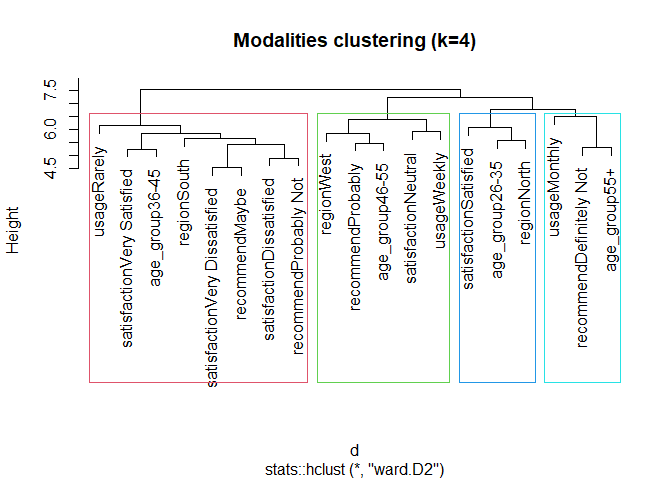

Hierarchical clustering dendrogram of modalities

```r
clusterer$plot_dendrogram()
```

### MCA Projection

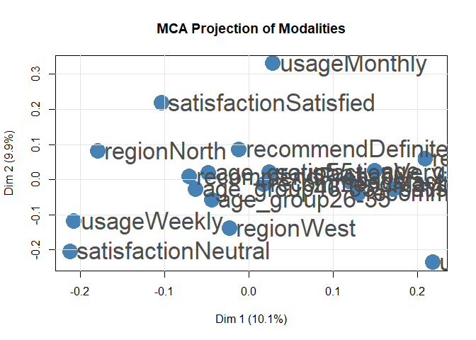

Modalities in MCA factorial space

```r
clusterer$plot_mca(show_labels = TRUE)
```

### Cluster Visualization

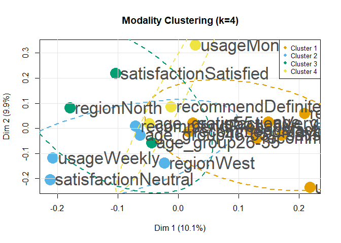

Modalities colored by cluster with confidence ellipses

```r
clusterer$plot_clusters(add_ellipses = TRUE)
```

## Working with Mixed Data

### Automatic Discretization

The `ModalitiesDiceClusterer` can handle mixed data (numeric + categorical) by automatically discretizing numeric variables into quantile bins.

```r
# Create mixed data
mixed_data <- survey_data
mixed_data$income <- rnorm(n, mean = 50000, sd = 15000)
mixed_data$age <- sample(18:70, n, replace = TRUE)
mixed_data$score <- runif(n, 0, 100)

str(mixed_data)
```

```
#> 'data.frame':    200 obs. of  8 variables:
#>  $ satisfaction: Factor w/ 5 levels "Dissatisfied",..: 3 1 2 1 4 3 2 1 5 2 ...
#>  $ recommend   : Factor w/ 5 levels "Definitely","Definitely Not",..: 5 1 3 5 3 2 5 5 5 1 ...
#>  $ usage       : Factor w/ 4 levels "Daily","Monthly",..: 4 4 3 2 2 1 4 3 3 4 ...
#>  $ age_group   : Factor w/ 5 levels "18-25","26-35",..: 2 2 2 4 1 5 5 3 3 5 ...
#>  $ region      : Factor w/ 4 levels "East","North",..: 1 2 2 3 3 4 1 3 3 2 ...
#>  $ income      : num  38722 51164 41148 53363 24266 ...
#>  $ age         : int  41 61 68 42 30 29 23 20 45 61 ...
#>  $ score       : num  41.2 88.6 49.6 67.3 28.3 ...
```

```r
# Fit with auto-discretization
clusterer_mixed <- ModalitiesDiceClusterer$new(
  n_groups = 5,
  linkage = "ward.D2",
  dissimilarity = "dice",
  auto_discretize = TRUE,
  n_bins = 4  # Quartiles
)
clusterer_mixed$fit(mixed_data)

cat("Modalities after discretization:\n")
```

```
#> Modalities after discretization:
```

```r
print(clusterer_mixed$get_modalities())
```

```
#>  [1] "satisfactionDissatisfied"      "satisfactionNeutral"
#>  [3] "satisfactionSatisfied"         "satisfactionVery Dissatisfied"
#>  [5] "satisfactionVery Satisfied"    "recommendDefinitely Not"
#>  [7] "recommendMaybe"                "recommendProbably"
#>  [9] "recommendProbably Not"         "usageMonthly"
#> [11] "usageRarely"                   "usageWeekly"
#> [13] "age_group26-35"                "age_group36-45"
#> [15] "age_group46-55"                "age_group55+"
#> [17] "regionNorth"                   "regionSouth"
#> [19] "regionWest"                    "incomeQ2"
#> [21] "incomeQ3"                      "incomeQ4"
#> [23] "ageQ2"                         "ageQ3"
#> [25] "ageQ4"                         "scoreQ2"
#> [27] "scoreQ3"                       "scoreQ4"
```

```r
cat("\nCluster assignments:\n")
```

```
#>
#> Cluster assignments:
```

```r
print(clusterer_mixed$get_cluster_table())
```

```
#>                         Modality Cluster Frequency
#> 1                    usageRarely       1        56
#> 2                       incomeQ2       1        50
#> 3                        scoreQ2       1        50
#> 4                    regionSouth       1        47
#> 5     satisfactionVery Satisfied       1        42
#> 6                 age_group36-45       1        39
#> 7          recommendProbably Not       1        33
#> 8       satisfactionDissatisfied       1        29
#> 9            satisfactionNeutral       2        57
#> 10                   usageWeekly       2        51
#> 11                       scoreQ3       2        50
#> 12                         ageQ2       2        48
#> 13         satisfactionSatisfied       3        54
#> 14                      incomeQ4       3        50
#> 15             recommendProbably       3        44
#> 16                age_group46-55       3        38
#> 17                  usageMonthly       4        59
#> 18                       scoreQ4       4        50
#> 19                   regionNorth       4        48
#> 20                         ageQ4       4        48
#> 21                age_group26-35       4        42
#> 22                recommendMaybe       4        29
#> 23 satisfactionVery Dissatisfied       4        18
#> 24                    regionWest       5        51
#> 25                         ageQ3       5        51
#> 26                      incomeQ3       5        50
#> 27       recommendDefinitely Not       5        49
#> 28                  age_group55+       5        37
```

### Controlling Discretization

```r
# Compare different bin counts
for (bins in c(3, 4, 5)) {
  clust <- ModalitiesDiceClusterer$new(
    n_groups = 4,
    auto_discretize = TRUE,
    n_bins = bins
  )
  clust$fit(mixed_data)
  cat(sprintf("n_bins=%d: %d modalities\n", bins, length(clust$get_modalities())))
}
```

```
#> n_bins=3: 25 modalities
#> n_bins=4: 28 modalities
#> n_bins=5: 31 modalities
```

## Re-cutting the Tree

After fitting, you can explore different numbers of clusters without re-computing distances:

```r
cat("=== Exploring Different k Values ===\n\n")
```

```
#> === Exploring Different k Values ===
```

```r
# Original clustering (k=4)
cat("Original (k=4):\n")
```

```
#> Original (k=4):
```

```r
print(table(clusterer$groups))
```

```
#>
#> 1 2 3 4
#> 8 5 3 3
```

```r
# Re-cut to k=3
clusterer$cut_tree(k = 3)
cat("\nAfter cut_tree(k=3):\n")
```

```
#>
#> After cut_tree(k=3):
```

```r
print(table(clusterer$groups))
```

```
#>
#> 1 2 3
#> 8 5 6
```

```r
# Re-cut to k=6
clusterer$cut_tree(k = 6)
cat("\nAfter cut_tree(k=6):\n")
```

```
#>
#> After cut_tree(k=6):
```

```r
print(table(clusterer$groups))
```

```
#>
#> 1 2 3 4 5 6
#> 8 2 3 2 3 1
```

```r
# Restore original
clusterer$cut_tree(k = 4)
```

## Illustrative Variables

Project supplementary (illustrative) variables onto the clustering without affecting it:

```r
# Create an illustrative variable
set.seed(456)
illus_var <- factor(sample(c("Segment A", "Segment B", "Segment C"),
                           n, replace = TRUE))

# Compute distances to clusters
illus_result <- clusterer$predict_illustrative(illus_var)

cat("Distances from illustrative modalities to clustered modalities:\n")
```

```
#> Distances from illustrative modalities to clustered modalities:
```

```r
print(round(illus_result$distances, 3))
```

```
#>                               Segment A Segment B Segment C
#> satisfactionDissatisfied           45.5      31.5      37.5
#> satisfactionNeutral                43.5      43.5      41.5
#> satisfactionSatisfied              41.0      46.0      40.0
#> satisfactionVery Dissatisfied      42.0      33.0      34.0
#> satisfactionVery Satisfied         45.0      39.0      37.0
#> recommendDefinitely Not            42.5      40.5      41.5
#> recommendMaybe                     47.5      35.5      31.5
#> recommendProbably                  43.0      39.0      40.0
#> recommendProbably Not              39.5      38.5      38.5
#> usageMonthly                       46.5      42.5      40.5
#> usageRarely                        47.0      43.0      38.0
#> usageWeekly                        42.5      38.5      44.5
#> age_group26-35                     44.0      37.0      40.0
#> age_group36-45                     45.5      39.5      34.5
#> age_group46-55                     43.0      38.0      38.0
#> age_group55+                       41.5      38.5      38.5
#> regionNorth                        46.0      42.0      36.0
#> regionSouth                        45.5      36.5      41.5
#> regionWest                         43.5      40.5      41.5
```

```r
cat("\nMean distances by cluster:\n")
```

```
#>
#> Mean distances by cluster:
```

```r
print(round(illus_result$by_group, 3))
```

```
#>   Segment A Segment B Segment C
#> 1    44.688    37.062    36.562
#> 2    43.100    39.900    41.100
#> 3    43.667    41.667    38.667
#> 4    43.500    40.500    40.167
```

### Visualizing with Illustrative Variable

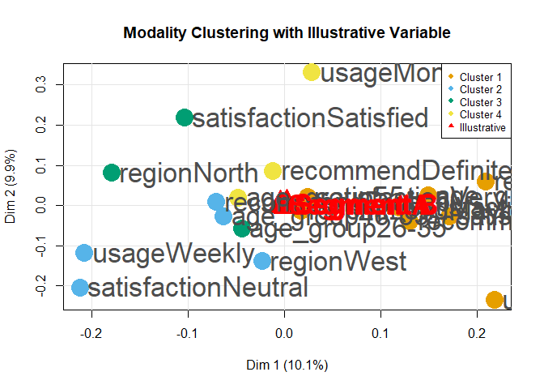

MCA projection with illustrative variable

```r
clusterer$plot_with_illustrative(illus_var)
```

## Extracting Data for Analysis

### MCA Coordinates

```r
mca_coords <- clusterer$get_mca_data(n_dims = 3)
head(mca_coords)
```

```
#>                        Modality     Variable             Level        Dim1
#> 1      satisfactionDissatisfied satisfaction      Dissatisfied  0.11961569
#> 2           satisfactionNeutral satisfaction           Neutral -0.21183514
#> 3         satisfactionSatisfied satisfaction         Satisfied -0.10345929
#> 4 satisfactionVery Dissatisfied satisfaction Very Dissatisfied  0.02437803
#> 5    satisfactionVery Satisfied satisfaction    Very Satisfied  0.17130071
#> 6       recommendDefinitely Not    recommend    Definitely Not -0.01127420
#>           Dim2        Dim3
#> 1 -0.005113965  0.01667502
#> 2 -0.205413136  0.02742087
#> 3  0.217606706  0.05816703
#> 4  0.020095874 -0.04876435
#> 5 -0.027175479 -0.05349858
#> 6  0.085402442 -0.18124374
```

### Cluster Data

```r
cluster_data <- clusterer$get_cluster_data()
head(cluster_data)
```

```
#>                     Modality     Variable          Level Cluster Frequency
#> 1                usageRarely        usage         Rarely       1        56
#> 2                regionSouth       region          South       1        47
#> 3 satisfactionVery Satisfied satisfaction Very Satisfied       1        42
#> 4             age_group36-45    age_group          36-45       1        39
#> 5      recommendProbably Not    recommend   Probably Not       1        33
#> 6   satisfactionDissatisfied satisfaction   Dissatisfied       1        29
#>        Dim1         Dim2 VarExplained_Dim1 VarExplained_Dim2
#> 1 0.2182472 -0.236217753          10.11454          9.881554
#> 2 0.2095684  0.059022747          10.11454          9.881554
#> 3 0.1713007 -0.027175479          10.11454          9.881554
#> 4 0.1494840  0.024119787          10.11454          9.881554
#> 5 0.1303229 -0.039766545          10.11454          9.881554
#> 6 0.1196157 -0.005113965          10.11454          9.881554
```

### Cluster Statistics

```r
cluster_stats <- clusterer$get_cluster_stats()
print(cluster_stats[, c("Cluster", "Size", "TotalFrequency", "AvgFrequency", "WithinVariance")])
```

```
#>   Cluster Size TotalFrequency AvgFrequency WithinVariance
#> 1       1    8            293     36.62500     0.01212602
#> 2       2    5            241     48.20000     0.01219174
#> 3       3    3            144     48.00000     0.01573204
#> 4       4    3            145     48.33333     0.01890461
```

## Silhouette Analysis

### Plotting Silhouette Scores

```
#> Computing silhouette scores for k = 2 to 8...
#>   k=2: avg silhouette = 0.0278
#>   k=3: avg silhouette = 0.0369
#>   k=4: avg silhouette = 0.0363
#>   k=5: avg silhouette = 0.0356
#>   k=6: avg silhouette = 0.0383
#>   k=7: avg silhouette = 0.0372
#>   k=8: avg silhouette = 0.0367
#>
#> Optimal k = 6 (avg silhouette = 0.0383)
```

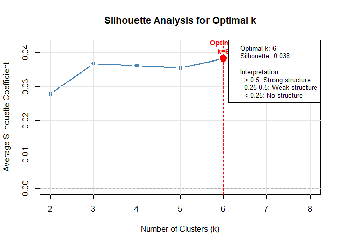

Silhouette analysis for optimal k

```r
clusterer$plot_silhouette(min_k = 2, max_k = 8)
```

### Detailed Silhouette Data

```r
sil_data <- clusterer$get_silhouette_data()
head(sil_data)
```

```
#>                     Modality Cluster Silhouette AvgDistWithin MinAvgDistOther
#> 1      recommendProbably Not       1 0.10823243      5.235329        5.870732
#> 2             age_group36-45       1 0.10465508      5.383022        6.012233
#> 3                usageRarely       1 0.08261369      5.797210        6.319268
#> 4                regionSouth       1 0.07366607      5.556573        5.998455
#> 5 satisfactionVery Satisfied       1 0.06347886      5.551319        5.927596
#> 6   satisfactionDissatisfied       1 0.05734495      5.272367        5.593103
#>   NearestCluster
#> 1              3
#> 2              2
#> 3              3
#> 4              4
#> 5              4
#> 6              4
```

```r
# Average silhouette by cluster
cat("\nAverage silhouette by cluster:\n")
```

```
#>
#> Average silhouette by cluster:
```

```r
print(aggregate(Silhouette ~ Cluster, data = sil_data, FUN = mean))
```

```
#>   Cluster  Silhouette
#> 1       1 0.070777161
#> 2       2 0.008021161
#> 3       3 0.022074398
#> 4       4 0.005625404
```

```r
# Poorly clustered modalities
poorly_clustered <- sil_data[sil_data$Silhouette < 0, ]
if (nrow(poorly_clustered) > 0) {
  cat("\nPoorly clustered modalities (silhouette < 0):\n")
  print(poorly_clustered)
} else {
  cat("\nNo poorly clustered modalities found.\n")
}
```

```
#>
#> Poorly clustered modalities (silhouette < 0):
#>             Modality Cluster   Silhouette AvgDistWithin MinAvgDistOther
#> 12 recommendProbably       2 -0.007295204      5.813184        5.770776
#> 13    age_group46-55       2 -0.025184388      5.753121        5.608232
#> 16    age_group26-35       3 -0.019638581      5.825263        5.710864
#> 18      usageMonthly       4 -0.008225090      6.204706        6.153672
#> 19      age_group55+       4 -0.014399153      5.727958        5.645481
#>    NearestCluster
#> 12              3
#> 13              1
#> 16              1
#> 18              1
#> 19              1
```

## Comparison with Variable Clustering

### When to Use Each Algorithm

Comparison of Clustering Algorithms

| Aspect | ModalitiesDiceClusterer | KMeansClusterer | DivisiveClusterer |
| --- | --- | --- | --- |
| Unit of analysis | Factor levels | Variables | Variables |
| Input data | Categorical (mixed OK) | Numeric (mixed OK) | Numeric (mixed OK) |
| Output | Groups of modalities | Groups of variables | Groups of variables |
| Dissimilarity | Dice / Cramer’s V | Correlation-based | PCA eigenvalues |
| Best for | Survey analysis, response patterns | Dimensionality reduction | Interpretable hierarchy |
| Hierarchy | Yes (hclust) | No | Yes (top-down) |

### Practical Example

```r
cat("=== Variable Clustering (KMeansClusterer) ===\n")
```

```
#> === Variable Clustering (KMeansClusterer) ===
```

```r
# Clusters variables together
km <- KMeansClusterer$new(data = survey_data, n_clusters = 3, seed = 42)
km$fit()
cat("Variable clusters:\n")
```

```
#> Variable clusters:
```

```r
print(km$get_results())
```

```
#>       variable cluster
#> 1 satisfaction       2
#> 2    recommend       3
#> 3        usage       2
#> 4    age_group       1
#> 5       region       1
```

```r
cat("\n=== Modality Clustering (ModalitiesDiceClusterer) ===\n")
```

```
#>
#> === Modality Clustering (ModalitiesDiceClusterer) ===
```

```r
# Clusters modalities (factor levels) together
cat("Modality clusters:\n")
```

```
#> Modality clusters:
```

```r
print(clusterer$get_cluster_table())
```

```
#>                         Modality Cluster Frequency
#> 1                    usageRarely       1        56
#> 2                    regionSouth       1        47
#> 3     satisfactionVery Satisfied       1        42
#> 4                 age_group36-45       1        39
#> 5          recommendProbably Not       1        33
#> 6       satisfactionDissatisfied       1        29
#> 7                 recommendMaybe       1        29
#> 8  satisfactionVery Dissatisfied       1        18
#> 9            satisfactionNeutral       2        57
#> 10                   usageWeekly       2        51
#> 11                    regionWest       2        51
#> 12             recommendProbably       2        44
#> 13                age_group46-55       2        38
#> 14         satisfactionSatisfied       3        54
#> 15                   regionNorth       3        48
#> 16                age_group26-35       3        42
#> 17                  usageMonthly       4        59
#> 18       recommendDefinitely Not       4        49
#> 19                  age_group55+       4        37
```

## Advanced Usage

### Chaining Methods

```r
# Method chaining for concise code
result <- ModalitiesDiceClusterer$new(n_groups = 4)$
  fit(survey_data)$
  cut_tree(5)$
  get_cluster_table()

print(result)
```

```
#>                         Modality Cluster Frequency
#> 1                    usageRarely       1        56
#> 2                    regionSouth       1        47
#> 3     satisfactionVery Satisfied       1        42
#> 4                 age_group36-45       1        39
#> 5          recommendProbably Not       1        33
#> 6       satisfactionDissatisfied       1        29
#> 7                 recommendMaybe       1        29
#> 8  satisfactionVery Dissatisfied       1        18
#> 9            satisfactionNeutral       2        57
#> 10                   usageWeekly       2        51
#> 11                    regionWest       2        51
#> 12             recommendProbably       2        44
#> 13                age_group46-55       2        38
#> 14         satisfactionSatisfied       3        54
#> 15                   regionNorth       3        48
#> 16                age_group26-35       3        42
#> 17       recommendDefinitely Not       4        49
#> 18                  age_group55+       4        37
#> 19                  usageMonthly       5        59
```

### Custom Analysis Pipeline

```r
# Complete analysis pipeline
analyze_modalities <- function(data, k_range = 2:8) {
  # Fit initial model
  clust <- ModalitiesDiceClusterer$new(n_groups = max(k_range))
  clust$fit(data)

  # Compute silhouette for each k
  results <- data.frame(k = k_range, avg_silhouette = NA, between_ratio = NA)

  for (i in seq_along(k_range)) {
    k <- k_range[i]
    clust$cut_tree(k)

    # Silhouette
    sil <- clust$get_silhouette_data()
    results$avg_silhouette[i] <- mean(sil$Silhouette)

    # Between/Total inertia
    summary_res <- clust$summary()
    results$between_ratio[i] <- summary_res$inertia["between"] / summary_res$inertia["total"]
  }

  return(results)
}

# Run analysis
analysis <- analyze_modalities(survey_data)
```

```
#> ================================================================================
#>                     MODALITIES DICE CLUSTERER SUMMARY
#> ================================================================================
#>
#> --- MODEL CONFIGURATION ---
#> Dissimilarity measure: DICE
#> Linkage method: ward.D2
#> Number of clusters: 2
#> Auto-discretization: Yes (n_bins=4)
#>
#> --- DATA INFORMATION ---
#> Number of observations: 200
#> Number of variables: 5
#> Number of modalities: 19
#> Modalities: satisfactionDissatisfied, satisfactionNeutral, satisfactionSatisfied, satisfactionVery Dissatisfied, satisfactionVery Satisfied, recommendDefinitely Not, recommendMaybe, recommendProbably, recommendProbably Not, usageMonthly, usageRarely, usageWeekly, age_group26-35, age_group36-45, a…
#>
#> --- CLUSTER ASSIGNMENTS ---
#> Cluster sizes (n_modalities): 8, 11
#>
#> Detailed cluster composition:
#>
#> Cluster 1 (8 modalities, total freq: 293):
#>   - usageRarely (freq: 56, 28.0%)
#>   - regionSouth (freq: 47, 23.5%)
#>   - satisfactionVery Satisfied (freq: 42, 21.0%)
#>   - age_group36-45 (freq: 39, 19.5%)
#>   - recommendProbably Not (freq: 33, 16.5%)
#>   - satisfactionDissatisfied (freq: 29, 14.5%)
#>   - recommendMaybe (freq: 29, 14.5%)
#>   - satisfactionVery Dissatisfied (freq: 18, 9.0%)
#>
#> Cluster 2 (11 modalities, total freq: 530):
#>   - usageMonthly (freq: 59, 29.5%)
#>   - satisfactionNeutral (freq: 57, 28.5%)
#>   - satisfactionSatisfied (freq: 54, 27.0%)
#>   - usageWeekly (freq: 51, 25.5%)
#>   - regionWest (freq: 51, 25.5%)
#>   - recommendDefinitely Not (freq: 49, 24.5%)
#>   - regionNorth (freq: 48, 24.0%)
#>   - recommendProbably (freq: 44, 22.0%)
```

[output cut: 505 more lines]

```
#>  7. recommendDefinitely Not (cluster 4): 0.1850 (5.83%)
#>  8. regionNorth (cluster 8): 0.1824 (5.75%)
#>  9. regionSouth (cluster 1): 0.1798 (5.67%)
#> 10. recommendProbably (cluster 5): 0.1716 (5.41%)
#>
#> --- DISTANCE MATRIX STATISTICS ---
#> Distance range: [4.5277, 7.5829]
#> Mean distance: 5.9280
#> Median distance: 5.9582
#>
#> --- HIERARCHICAL CLUSTERING DETAILS ---
#> Height range: [4.5277, 7.5219]
#> Number of merges: 18
#>
#> ================================================================================
```

```r
print(analysis)
```

```
#>   k avg_silhouette between_ratio
#> 1 2     0.02784746     0.1083528
#> 2 3     0.03688417     0.1903993
#> 3 4     0.03628539     0.2626839
#> 4 5     0.03561459     0.3262335
#> 5 6     0.03825081     0.3884983
#> 6 7     0.03720447     0.4416364
#> 7 8     0.03668636     0.4991403
```

```r
# Recommend k
best_k <- analysis$k[which.max(analysis$avg_silhouette)]
cat(sprintf("\nRecommended k (by silhouette): %d\n", best_k))
```

```
#>
#> Recommended k (by silhouette): 6
```

## Parameters Summary

| Parameter | Default | Description |
| --- | --- | --- |
| `n_groups` | 3 | Number of modality clusters |
| `linkage` | `"ward.D2"` | Hierarchical clustering linkage method |
| `dissimilarity` | `"dice"` | `"dice"` or `"cramer"` |
| `auto_discretize` | `TRUE` | Discretize numeric variables |
| `n_bins` | 4 | Number of quantile bins for discretization |

## Interpretation Tips

1. **Cluster composition**: Look for modalities from different variables that group together - they represent similar response patterns
2. **Inertia decomposition**: Higher between-cluster inertia indicates better separation
3. **Silhouette scores**:
   - > 0.5: Strong structure
   - 0.25-0.5: Weak structure
   - < 0.25: No substantial structure
4. **MCA visualization**: Proximity in the MCA space indicates similar co-occurrence patterns
5. **Illustrative projection**: Helps understand how external variables relate to the clustering

## Conclusion

The `ModalitiesDiceClusterer` provides a unique perspective on categorical data by clustering modalities rather than variables. This is particularly valuable for:

- Understanding response patterns in surveys
- Identifying groups of similar categories across variables
- Simplifying complex categorical structures
- Preparing data for further multivariate analysis

For variable clustering (grouping correlated columns), use `KMeansClusterer` or `DivisiveClusterer` instead.

## References

- Lebart, L., Morineau, A., & Piron, M. (2000). *Statistique exploratoire multidimensionnelle*. Dunod.
- Escofier, B., & Pagès, J. (2008). *Analyses factorielles simples et multiples*. Dunod.
- Dice, L. R. (1945). Measures of the Amount of Ecologic Association Between Species. *Ecology*, 26(3), 297-302.